# Datos Atípicos o Outliers

Estadística Descriptiva

11/9/2020

## Diagramas de Caja y Bigotes

El *diagrama de caja y bigotes* es una técnica de graficación relativamente moderna y sencilla, que permite apreciar las características principales de los datos y con ello tener una idea aproximada de la distribución. Asimismo, nos permite en una sola gráfica comparar la distribución de varios conjuntos de datos, ello con el objetivo de determinar las diferencias principales de los datos.

Un diagrama de caja y bigotes se construye de la siguiente manera:

- Se colocan líneas verticales en cinco posiciones, las que corresponden, respectivamente
  - al valor más pequeño de la lista de datos,
  - al primer cuartil (el *cuartil inferior*),
  - a la mediana,
  - al tercer cuartil (el *cuartil superior*) y
  - al valor más grande de la lista de datos.

  Estos cinco números se conocen frecuentemente como **el resumen de cinco números** (*five number summary* en  
  Inglés).
- Una caja es dibujada entre las posiciones correspondientes al primer y tercer cuartil.
- A la vez, dos segmentos de recta horizontales (los **bigotes**) conectan la caja (por supuesto, partiendo del primer y tercer cuartiles) con los dos valores extremos arriba indicados. Específicamente, el bigote izquierdo conecta el valor más pequeño de la lista con el primer cuartil; mientras que el bigote derecho conecta el tercer cuartil con el valor más grande de la lista.

Un diagrama de cajas debe verse de la siguiente manera:

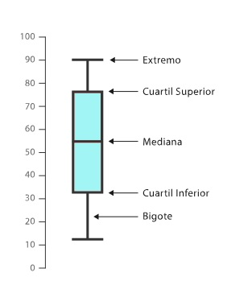

Con un diagrama de caja y bigotes, podemos definir una medida simple de dispersión mediante la distancia entre el primer y tercer cuartil. Esta distancia se conoce como el **rango intercuartil** (representado como $IQR$) y es una medida de la dispersión de la mitad intermedia de los datos. Esta última expresión debe resultar obvia, dado que el $25\%$ de los datos se ubica entre el valor más pequeño de la lista y el primer cuartil; otro $25\%$ de datos se ubica entre el primer y segundo cuartil (recordar que el segundo cuartil es la mediana de todos los datos); el tercer $25\%$ de datos, por supuesto, se ubica entre el segundo y tercer cuartil, mientras que el último $25\%$ de los datos se ubica entre el tercer cuartil y el valor más grande de los mismos. De aquí resulta que entre el primer y tercer cuartiles se ubica el $50\%$ (**mitad intermedia**) de los datos.

**Ejemplo 1**

Cuarenta estudiantes tomaron el examen de admisión a la universidad y los resultados del mismo se resumen en el diagrama de caja y bigotes de abajo.

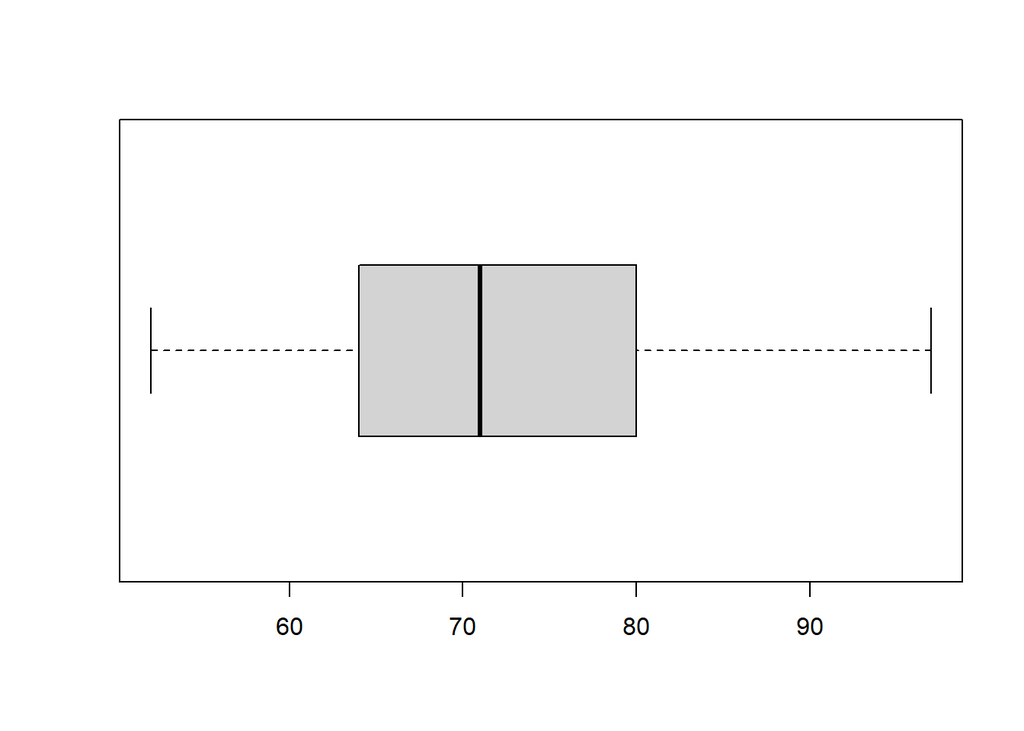

Del diagrama podemos obtener la siguiente información:

   Ya que $71$ es la mediana, entonces hay $20$ estudiantes por encima de esa nota, la mitad de los estudiantes.

**Ejemplo 2:**

Los diagramas de caja y bigotes mostrados abajo representan los tiempos hechos por cada alumno de una clase durante una carrera de 150 metros con obstáculos. Los tiempos se han separado según género, es decir, tanto para el grupo de muchachos como para el de muchachas. Cada uno de dichos grupos cree que posee los mejores tiempos. Determinar el resumen de cinco números para cada grupo. Proporcionar un argumento convincente para cada grupo.

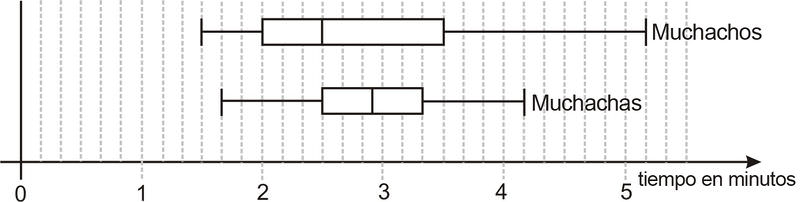

La comparación de los dos conjuntos de datos mediante diagramas de caja y bigotes es relativamente sencillo. Por ejemplo, puedes observar, tanto a través del rango como del rango intercuartil, que los datos para los muchachos están más esparcidos.

**Muchachos**

- Los muchachos poseen la marca de tiempo más corto (1 minutos 30 segundos), de donde se concluye que el individuo más rápido fue un muchacho.
- Los muchachos también tienen la mediana más pequeña (2 min 30 segundos); lo que significa que la mitad de los muchachos habían terminado la carrera cuando solamente un cuarto de las muchachas lo había hecho (sabemos que únicamente un cuarto de las muchachas había terminado porque su primer cuartil fue también de 2:30).

**Muchachas**

- Los muchachos tuvieron el tiempo más largo (5 minutos 10 segundos), de modo que para cuando todas las muchachas ya habían terminado, aun quedaba, al menos, un muchacho sin completar la carrera.
- Las muchachas tuvieron el tercer cuartil más pequeño. (3 min 20 segundos); lo que significa que aun sin tomar en cuenta el cuarto de tiempos más largos, las muchachas fueron las más rápidas.

## Outliers o datos atípicos

Un **outlier** o **dato atípico** es un dato que no encaja bien dentro de la distribución de los otros datos en una lista. Se dice también que son aquellas observaciones que está muy distante del resto de los datos. Para el caso de los diagramas de caja y bigotes, podemos definir cuáles puntos son outliers de acuerdo a la distancia que los separa de la caja del diagrama. En general, el determinar cuáles datos son outliers responde, de algún modo, a criterios arbitrarios. Sin embargo,muchos libros siguen la norma que sigue, en la que nuestra medida básica de distancia será el rango intercuartil ($IQR$, según sus siglas en Inglés).

Se dice que un valor es un valor atípico si es mayor que $Q_3 + 1.5 \cdot IQR$ (valor atípico a la derecha), o es menor que $Q_1 - 1.5 \cdot IQR$ (valor atípico a la izquierda), siendo $Q_1$ el primer cuartil, $Q_3$ el tercer cuartil y $IQR$ el rango intercuartil ($Q_3 - Q_1$) que representa el ancho de la caja para diagramas de caja cuando la tenemos en forma horizontal.

Ahora vamos a construir el diagrama de caja y bigotes, pero pensando en que nos presente también los datos atípicos que están presentes en los datos:

1. Ordenar los datos.
2. Calcular los tres cuartiles ($Q_1$, $Q_2$ y $Q_3$). Después, dibujamos el rectángulo (caja) delimitado por el primer y tercer cuartil, dibujando entre los dos cuartiles una línea para indicar donde está la mediana (segundo cuartil o $Q_2$).
3. Calcular el rango intercuartílico, que es el tercer cuartil menos el primero.

$$IQR = Q_3 - Q_1$$

4. Se calculan los límites admisibles inferior y superior ($L_I$ y $L_S$) para identificar los valores extremos.

$$\begin{align}
L_I &= Q_1 - 1.5 \cdot IQR \\
L_S &= Q_3 + 1.5 \cdot IQR
\end{align}$$

Los límites marcarán los datos atípicos de la variable. Todos aquellos puntos que sean menores que $L_I \, (x < L_I)$ o mayores que $L_S \, (x > L_S)$ son valores extremos. Es decir, son todos aquellos valores que no están en el intervalo $[LI,LS]$.

5. El **mínimo** es el menor valor del conjunto que sea mayor o igual que $L_I$. El **máximo** es el mayor valor del conjunto que es menor o igual que $L_S$. Dibujamos los dos **brazos**. El primero va desde el primer cuartil hasta el mínimo. El segundo, desde el tercer cuartil hasta el máximo.
6. Se dibujan los **valores extremos** o atípicos, representados por puntos o círculos pequeños.

**Ejemplo**

En un bosque plantaron veinte ($N=20$) árboles y, al cabo de unos años, se mide la altura para ver su evolución. Un muy buen método para ver cómo han crecido y comprobar si existen valores extremos es el **diagrama de caja**. Mediante esta representación gráfica podemos ver si hay árboles que han crecido más o menos de lo habitual.

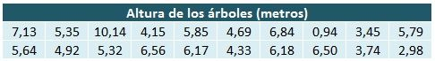

1. Se **ordenan los datos**.
2. Se calculan los **tres cuartiles**.

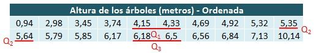

A partir del conjunto ordenado calculamos los cuartiles

- El menor valor es $0.94$.
- El primer cuartil $Q_1 = \frac{4.15+4.33}{2} = 4.24$
- El segundo cuartil o mediana $Q_2 = \frac{5.35 + 5.64}{2} = 5.50$
- El tercer cuartil $Q_3 = \frac{6.18 + 6.5}{2} = 6.34$
- El mayor valor es $10.14$
3. Se calculan los **límites admisibles inferior** y **superior** ($L_I$ y $L_S$) para determinar los valores extremos. El **rango intercuartílico** es $IQR = Q_3 - Q_1 = 6.34 - 4.24 = 2.1$. A partir del rango calculamos los límites:

$$\begin{align}
L_I &= Q_1 - 1.5 \times IQR = 4.24 - 1.5 \times 2.1 = 1.09 \\
L_S &= Q_3 + 1.5 \times IQR = 6.34 + 1.5 \times 2.1 = 9.49
\end{align}$$
Los valores extremos serán todos los árboles que midan menos de $1.09m$ o más de $9,49m$. Tenemos dos árboles, uno de $0.94m$ y otro de $10.14m$ que serán valores extremos. Estos valores los representamos con puntos en el **diagrama de caja**.

4. El **mínimo** es el menor elemento del conjunto que sea mayor o igual al límite inferior. El **máximo** es el mayor elemento que sea menor o igual al límite superior. En este caso, el mínimo es $2.98$ y el máximo $7.13$
5. Se dibujan los **brazos** del diagrama de caja. El brazo inferior irá desde el primer cuartil hasta el mínimo (desde el $4.24$ a $2.98$). El brazo superior abarcará desde el tercer cuartil hasta el máximo (desde el $6.34$ hasta el $7.13$).
6. Los dos **puntos extremos** o datos atípicos se representan mediante un punto o círculo.

El **diagrama de caja** del conjunto de la altura de estos veinte árboles es:

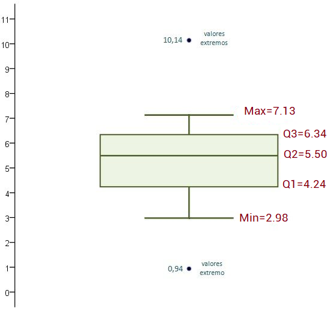

## Diagramas de caja en R

En R base se puede crear un gráfico caja y bigotes con la función `boxplot`. Para dibujar el diagrama, solo necesitams pasar un vector con los datos a la función anterior. Por defecto, el diagrama de caja será vertical, pero se puede cambiar la orientación estableciendo el argumento `horizontal` como `TRUE`.

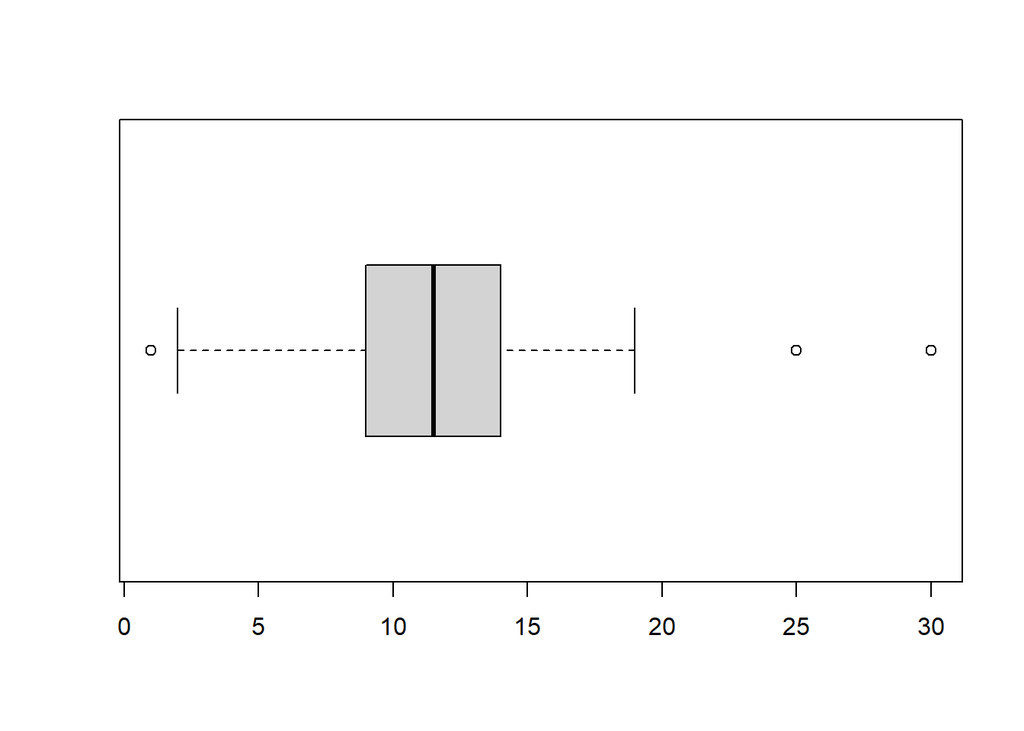

```r
x <- c(1,2,5,9,10,10,11,12,13,13,14,19,25,30)

boxplot(x, horizontal = TRUE)
```

Ten en cuenta que los diagramas de caja ocultan la distribución subyacente de los datos. Para resolver este problema, puedes agregar puntos al boxplot con la función `stripchart` (el método `jitter` evitará dibujar sobre los datos atípicos) de la siguiente manera:

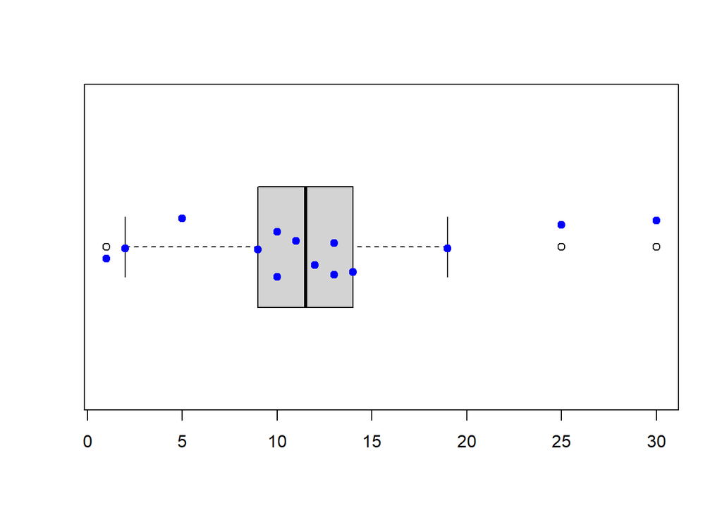

```r
x <- c(1,2,5,9,10,10,11,12,13,13,14,19,25,30)

boxplot(x, horizontal = TRUE)

stripchart(x, method = "jitter", pch = 19, add = TRUE, col = "blue")
```